# Aplicaciones del Big Data en la empresa

### 3.1.6 Aplicando Target Encoding

#### 3.1.6.1 Empleando la media

Otra técnica propuesta para la codificación de *fe_ward* y *fe_funder* consiste en **reemplazar cada categoría por la agregación de la variable objetivo**, reemplazando las variables objetivo por valores numéricos (0, 1 y 2) y sustituir cada categoría en *fe_ward* y *fe_funder* por el promedio de dicha variable. A modo de ejemplo:

```
   student grades grades_mean_by_student
1:   Marie      0                   0.75 = (0 + 0 + 1 + 2 / 4)
2:   Marie      0                   0.75
3:  Pierre      1                   1.00
4:   Louis      2                   1.75
5:   Louis      2                   1.75
6:   Marie      1                   0.75
7:   Marie      2                   0.75
8:   Louis      2                   1.75
9:   Louis      1                   1.75
```

Para aplicar *target_encoding*, recuperamos únicamente las variables categóricas *fe_ward* y *fe_funder*:

```r
# Recuperamos las columnas categoricas
datcat_df <- as.data.frame(datcompleto %>% select(fe_funder, fe_ward))
```

En muchas ocasiones, se recomienda añadir un valor de “ruido aleatorio” a las columnas del conjunto de entrenamiento por lo que separaremos nuevamente *datcompleto* en entrenamiento y prueba:

```r
# Dividimos datcompleto en entrenamiento y prueba
train <- datcompleto[c(1:fila_test-1),]
train$status_group <- vector_status_group
train$status_group <- as.factor(train$status_group)

test <- datcompleto[c(fila_test:nrow(datcompleto)),]
```

A continuación, de cara la codificación **convertimos la variable objetivo en formato numérico**:

```r
# 0: functional ;  1: functional needs repair ; 2: non functional
train[, status_group := ifelse(status_group == "functional", 0,
                               ifelse(status_group == "functional needs repair", 1
                                      , 2))]
```

Para realizar *Target Encoding*, empleamos la función *build_target_encoding* disponible en el paquete *DataPreparation*, sobre la que debemos indicar el conjunto de entrenamiento, el nombre las columnas a codificar, la variable objetivo, así como la función de agregación (en este caso la media):

```r
#-- Target encoding (mean)
dat_encoded <- build_target_encoding(train,
                                      cols_to_encode = names(datcat_df),
                                      target_col = "status_group",
                                      functions = "mean",
                                      verbose = TRUE)
```

```
## [1] "build_target_encoding: Start to compute encoding for target_encoding according to col: status_group."
```

Dicha función devuelve una lista con la correspondencia entre cada categoría y su valor codificado mediante *Target Encoding*. Veamos un ejemplo:

```r
# Creamos un data.table para observar los resultados obtenidos tras aplicar Target Encoding
dat_encoded_dt          <- as.data.table(dat_encoded)
names(dat_encoded_dt)   <- stri_replace_all_regex(names(dat_encoded_dt),
                                                  pattern = ".*\\.",
                                                  replacement = "")

dat_encoded_dt[1, ] # Veamos un ejemplo
```

```
##    fe_funder status_group_mean_by_fe_funder  fe_ward
## 1:     roman                      0.3236364 mundindi
##    status_group_mean_by_fe_ward
## 1:                         0.75
```

Tras obtener el *Target Encoding* de cada categoría, **debemos sustituir el valor de cada categoría por su agregación correspondiente**. tanto en el conjunto *train* como *test*. Para ello, empleamos la función *target_encode*:

```r
train <- target_encode(train, target_encoding = dat_encoded)
```

```
## [1] "target_encode: Start to encode columns according to target."
```

```r
test <- target_encode(test, target_encoding = dat_encoded)
```

```
## [1] "target_encode: Start to encode columns according to target."
```

```r
sum(is.na(test)) # 21 valores missing en status_group_by_fe_funder
```

```
## [1] 259
```

```r
# Reemplazamos los valores nulos por la media
media <- mean(test[, status_group_mean_by_fe_funder], na.rm = TRUE)
setnafill(test, cols="status_group_mean_by_fe_funder", fill = media)
```

A continuación, añadimos un valor de ruido al conjunto *train*, además de recodificar la variable objetivo y eliminar las columnas *fe_ward* y *fe_funder* originales:

```r
# Añadimos ruido a los datos train
cat_cols <- paste0('status_group_mean_by_',names(datcat_df))

train[, cat_cols] <- train[, lapply(.SD,
                                    function(x) x * rnorm(length(x), mean = 1,
                                    sd = 0.05)), .SDcols = cat_cols]

# Recodificamos la variable objetivo
train[, status_group := ifelse(status_group == 0, "functional",
                               ifelse(status_group == 1, "functional needs repair"
                                      , "non functional"))]

# Eliminamos las variables originales
train[, `:=`(fe_funder = NULL, fe_ward = NULL)]
test[, `:=`(fe_funder = NULL, fe_ward = NULL)]
```

Finalmente, entrenamos el modelo y realizamos las predicciones sobre el conjunto *test*:

```r
#-- Modelo
formula   <- as.formula("status_group~.")
# 0.8154377
my_model_11 <- fit_random_forest(formula,
                                 train)
```

```
[1] 0.8154377
39.044 sec elapsed
```

```r
my_sub_11 <- make_predictions(my_model_11, test)

# guardo submission
fwrite(my_sub_11, file = "./submissions/11_lumping_fe_sobre_funder_ward_target_encoding_media.csv")
```

|  | Train.accuracy | Data.Submission |
| --- | --- | --- |
| Mejor accuracy en el concurso | - | 0.8180 |
| Num + Cat (> 1 & < 2100) fe anteriores + fe_funder + fe_ward | 0.8149832 | 0.8197 |
| Num + Cat (> 1 & < 2100) fe anteriores + lumping sobre funder + ward (mediana) | 0.8159764 | 0.8212 |
| Num + Cat (> 1 & < 2100) fe anteriores + lumping sobre funder + ward (tercer cuartil) | 0.8146633 | 0.8203 |
| Num + Cat (> 1 & < 2100) fe anteriores + lumping sobre funder + ward (primer cuartil) | 0.8159259 | 0.8196 |
| Num + Cat (> 1 & < 2100) fe anteriores + lumping (mediana) + hashed sobre funder + ward | 0.8158418 | 0.8214 |
| Num + Cat (> 1 & < 2100) fe anteriores + lumping (mediana) + freq. abs. sobre funder + ward | 0.8154882 | 0.8216 |
| Num + Cat (> 1 & < 2100) fe anteriores + lumping (mediana) + freq. abs. y target enc. (media) sobre funder + ward | 0.8154377 | 0.8164 |

#### 3.1.6.2 Empleando la suma

Revisando la documentación de la función *build_target_encoding*, me llamó la atención un ejemplo propuesto en el que se emplea la función la agregación *sum* en lugar de la media. A modo de ejemplo, supongamos el siguiente *data.table* con diferentes bombas de agua:

```
     fe_funder    fe_ward   status_group
1:       roman   mundindi              0
2:       other      natta              1
3:      unicef      other              1
4:      unicef      natta              2
5:       other   mundindi              0

0: non functional ;  1: functional needs repair ; 2: functional
```

¿Y si en lugar de aplicar la media **realizamos la suma de los pesos de cada variable objetivo**? Es decir, dado que cada categoría tiene un valor asignado (0, 1 o 2), una posibilidad sería **calcular el total de la variable objetivo por cada categoría**. De este modo:

```
     fe_funder    fe_ward   status_group     fe_funder_sum     fe_ward_sum
1:       roman   mundindi              0                 0       0 + 0 = 0
2:       other      natta              1         1 + 0 = 1       1 + 2 = 3
3:      unicef      other              1         1 + 2 = 3               1
4:      unicef      natta              2         1 + 2 = 3       1 + 2 = 3
5:       other   mundindi              0         1 + 0 = 1       0 + 0 = 0

0: non functional ;  1: functional needs repair ; 2: functional
```

```
     fe_funder   status_group     fe_funder_sum
1:       roman              2                 2
2:      unicef              1         1 + 1 = 2
3:      unicef              1         1 + 1 = 2

0: non functional ;  1: functional needs repair ; 2: functional
```

No obstante, **probaremos con un nuevo modelo**, comprobando si los resultandos mejoran:

```r
#-- Target encoding (sum)
dat_encoded <- build_target_encoding(train,
                                      cols_to_encode = names(datcat_df),
                                      target_col = "status_group",
                                      functions = "sum",
                                      verbose = TRUE)
```

|  | Train.accuracy | Data.Submission |
| --- | --- | --- |
| Mejor accuracy en el concurso | - | 0.8180 |
| Num + Cat (> 1 & < 2100) fe anteriores + fe_funder + fe_ward | 0.8149832 | 0.8197 |
| Num + Cat (> 1 & < 2100) fe anteriores + lumping sobre funder + ward (mediana) | 0.8159764 | 0.8212 |
| Num + Cat (> 1 & < 2100) fe anteriores + lumping sobre funder + ward (tercer cuartil) | 0.8146633 | 0.8203 |
| Num + Cat (> 1 & < 2100) fe anteriores + lumping sobre funder + ward (primer cuartil) | 0.8159259 | 0.8196 |
| Num + Cat (> 1 & < 2100) fe anteriores + lumping (mediana) + hashed sobre funder + ward | 0.8158418 | 0.8214 |
| Num + Cat (> 1 & < 2100) fe anteriores + lumping (mediana) + freq. abs. sobre funder + ward | 0.8154882 | 0.8216 |
| Num + Cat (> 1 & < 2100) fe anteriores + lumping (mediana) + freq. abs. y target enc. (media) sobre funder + ward | 0.8154377 | 0.8164 |
| Num + Cat (> 1 & < 2100) fe anteriores + lumping (mediana) + freq. abs. y target enc. (suma) sobre funder + ward | 0.814899 | 0.8215 |

Curiosamente, el resultado obtenido **mejora con respecto al cálculo mediante la media, aunque sigue siendo mejor (por poca diferencia), la codificación por frecuencias absolutas**.

### 3.1.7 Aplicando Word Embedding

Sin duda, uno de los grandes avances en el campo de la lingüística han sido las técnicas de *Word Embedding*, que permiten **la representación vectorial (n-dimensional) de una palabra o *token***. Por ello, de cara a la práctica se planteó la posibilidad de **realizar una representación vectorial de las diferentes categorías en las columnas *fe_ward* y *fe_funder***, con el objetivo de observar si la precisión del modelo mejora o no.

Para ello, haremos uso de dos paquetes:

1. *embed*: permite la creación de modelos *word-embedding*, mediante el uso de la librería *TensorFlow*.
2. *recipes*: pertenciente al paquete *tidymodels*, se emplea fundamentalmente para el preprocesamiento de datos, mediante el uso de “recetas” definidas de forma secuencial por medios de *pipelines*.

En primer lugar, y una vez aplicado *lumping* sobre *ward* y *funder*, **dividimos nuevamente los datos en entrenamiento y test**:

```r
# 1. Comprobamos que las variables categoricas estan codificadas como factor
emb_cols <- c("fe_ward", "fe_funder")
datcompleto[,(emb_cols):= lapply(.SD, as.factor), .SDcols = emb_cols]

# Dividimos en train y test
train <- datcompleto[c(1:fila_test-1),]
train$status_group <- vector_status_group
train$status_group <- as.factor(train$status_group)

test <- datcompleto[c(fila_test:nrow(datcompleto)),]
```

Una vez dividido el conjunto de datos, elaboramos el modelo *embedded*. Para ello, mediante la función *recipe* elaboramos una “receta” para la transformación de variables, concretamente sobre *fe_ward*, *fe_funder* y *status_group*. Sobre dicha receta o fórmula aplicamos la función *step_embed* del paquete *embed*, con la que realizar la transformación *Word Embedding*. Por defecto, el número de dimensiones es de 2, por lo que probaremos inicialmente con dicho valor:

```r
# 2. Elaboramos el modelo embedded (empezando con dimensionalidad 2)
emb_cols_target <- c(emb_cols, "status_group")

base_recipe <- recipe(status_group ~ ., train[, ..emb_cols_target])
for(feat in emb_cols){
  base_recipe <- base_recipe %>%
    step_embed({{feat}},
                num_terms = 2,
                outcome = vars(status_group),
                options = embed_control(epochs = 5, validation_split = 0.2)
    )
}
```

Finalmente, una vez elaborada la “receta” para la transformación de ambas columnas, **la aplicamos inicialmente sobre el conjunto *train* y posteriormente sobre el conjunto *test***, haciendo uso de las funciones *prep* y *bake*, respectivamente:

```r
# 3. Creacion de las columnas Word Embeddings (train y test)
train_prepped <- prep(base_recipe, train[, ..emb_cols_target])
test_prepped <-  bake(train_prepped, test[, ..emb_cols])

train_final  <- cbind(as.data.table(juice(train_prepped)),
                      train[, setdiff(names(train), emb_cols_target), with = FALSE]
                )

test_final  <- cbind(test_prepped,
                     test[, setdiff(names(test), emb_cols), with = FALSE]
                )
# Echemos un vistazo a las columnas transformadas
train_final[1, c("fe_ward_embed_1", "fe_ward_embed_2", "fe_funder_embed_1", "fe_funder_embed_2")]
```

```
##    fe_ward_embed_1 fe_ward_embed_2 fe_funder_embed_1 fe_funder_embed_2
## 1:    -0.002076114      0.02586615        0.03580488        0.01154404
```

Como podemos comprobar, cada categoría se transforma en dos columnas con su representación bi-dimensional correspondiente ¿Mejorará el modelo si aplicamos Word Embedding sobre *fe_ward* y *fe_funder*?

```r
# Train
my_model_12 <- fit_random_forest(formula, train_final)

# Predicciones
my_sub_12  <- make_predictions(my_model_12, test_final)
```

|  | Train.accuracy | Data.Submission |
| --- | --- | --- |
| Mejor accuracy en el concurso | - | 0.8180 |
| Num + Cat (> 1 & < 2100) fe anteriores + fe_funder + fe_ward | 0.8149832 | 0.8197 |
| Num + Cat (> 1 & < 2100) fe anteriores + lumping sobre funder + ward (mediana) | 0.8159764 | 0.8212 |
| Num + Cat (> 1 & < 2100) fe anteriores + lumping sobre funder + ward (tercer cuartil) | 0.8146633 | 0.8203 |
| Num + Cat (> 1 & < 2100) fe anteriores + lumping sobre funder + ward (primer cuartil) | 0.8159259 | 0.8196 |
| Num + Cat (> 1 & < 2100) fe anteriores + lumping (mediana) + hashed sobre funder + ward | 0.8158418 | 0.8214 |
| Num + Cat (> 1 & < 2100) fe anteriores + lumping (mediana) + freq. abs. sobre funder + ward | 0.8154882 | 0.8216 |
| Num + Cat (> 1 & < 2100) fe anteriores + lumping (mediana) + freq. abs. y target enc. (media) sobre funder + ward | 0.8154377 | 0.8164 |
| Num + Cat (> 1 & < 2100) fe anteriores + lumping (mediana) + freq. abs. y target enc. (suma) sobre funder + ward | 0.814899 | 0.8215 |
| Num + Cat (> 1 & < 2100) fe anteriores + lumping (mediana) + word embed sobre funder y ward (dim = 2) | 0.8155724 | 0.8204 |

Creando un modelo *Word Embedding* sobre ambas variables, el resultado no parece mejorar ¿Y si aumentamos el número de dimensiones en la representación vectorial? Normalmente, los modelos *Word Embedding* suelen emplear decenas e incluso cientas de dimensiones en su representación.

|  | Train.accuracy | Data.Submission |
| --- | --- | --- |
| Word Embedding (Dim = 2) | 0.8155724 | 0.8204 |
| Word Embedding (Dim = 5) | 0.8150337 | 0.8192 |
| Word Embedding (Dim = 10) | 0.8145286 | 0.8157 |

Pese a aumentar el número de dimensiones (y con ello la complejidad), la precisión del modelo disminuye.

**Conclusión**: dado el mejor *score* obtenido, elegimos como mejor alternativa **la transformación por frecuencias absolutas**.

### 3.1.8 Transformar por frecuencias absolutas el resto de variables categóricas

A la vista de las transformaciones anteriores, la que mejor resultado ha obtenido ha sido mediante frecuencias absolutas. No obstante, y dado que solo las hemos aplicado sobre *fe_ward* y *fe_funder* ¿Y si la aplicamos sobre el resto de variables categóricas, concretamente de tipo carácter?

Para ello, y una vez aplicado *lumping* sobre *ward* y *funder*, **realizamos la imputación de las variables categóricas (character) por sus correspondientes frecuencias absolutas**. Inicialmente, almacenamos en una variable los nombres de las columnas a imputar:

```r
#-- Imputacion de las variables categoricas por sus frecuencias absolutas
cat_cols <- names(datcompleto[, which(sapply(datcompleto, is.character)), with = FALSE])
```

Antes de realizar la imputación, guardamos en una variable el número de valores únicos de cada columna:

```r
#   Antes de imputar
freq_antes_fe <- apply(datcompleto[, ..cat_cols], 2, function(x) length(unique(x)))
```

A continuación, **sustituimos el valor de cada columna por su correspondiente frecuencia absoluta, además de eliminar las columnas originales**:

```r
# Sustitucion de cada valor por su frecuencia absoluta
for (cat_col in cat_cols) {
  datcompleto[, paste0("fe_", cat_col) := as.numeric(.N), by = cat_col]
}
# fe_funder y fe_ward aparecen como fe_fe_ward y fe_fe_funder
# por lo que lo reemplazamos por fe_ward y fe_funder
names(datcompleto) <- stri_replace_all_fixed(names(datcompleto),
                                             "fe_fe_", "fe_")

# Eliminamos las columnas originales
for (cat_col in cat_cols) {
  datcompleto[, paste(cat_col) := NULL]
}
```

Una vez transformadas las columnas, creamos una nueva variable con el número de valores únicos de cada columna:

```r
new_cat_cols <- paste0("fe_", stri_replace_all_fixed(cat_cols, "fe_", ""))

freq_despues_fe <- apply(datcompleto[, ..new_cat_cols], 2, function(x) length(unique(x)))

#-- Solo cambian funder, ward y lga en relacion al numero de categorias
data.table(rbind(freq_antes_fe, freq_despues_fe), keep.rownames = TRUE)
```

```
##                 rn basin region lga scheme_management extraction_type
## 1:   freq_antes_fe     9     21 125                13              18
## 2: freq_despues_fe     9     21 120                13              18
##    extraction_type_group extraction_type_class management management_group
## 1:                    13                     7         12                5
## 2:                    13                     7         12                5
##    payment water_quality quality_group quantity source source_type source_class
## 1:       7             8             6        5     10           7            3
## 2:       7             8             6        5     10           7            3
##    waterpoint_type waterpoint_type_group funder ward fe_funder fe_ward
## 1:               7                     6   2141 2098      2110    2096
## 2:               7                     6    155  148       155     148
```

Analizando la tabla resultante, podemos comprobar como tan solo *funder*, *ward* y *lga* se ven reducidos en cuanto al número de valores únicos se refiere. No obstante, veamos los resultados obtenidos tras entrenar el nuevo modelo:

```r
my_model_13 <- fit_random_forest(formula, train)

my_sub_13   <- make_predictions(my_model_13, test)
```

|  | Train.accuracy | Data.Submission |
| --- | --- | --- |
| Mejor accuracy en el concurso | - | 0.8180 |
| Num + Cat (> 1 & < 2100) fe anteriores + fe_funder + fe_ward | 0.8149832 | 0.8197 |
| Num + Cat (> 1 & < 2100) fe anteriores + lumping sobre funder + ward (mediana) | 0.8159764 | 0.8212 |
| Num + Cat (> 1 & < 2100) fe anteriores + lumping sobre funder + ward (tercer cuartil) | 0.8146633 | 0.8203 |
| Num + Cat (> 1 & < 2100) fe anteriores + lumping sobre funder + ward (primer cuartil) | 0.8159259 | 0.8196 |
| Num + Cat (> 1 & < 2100) fe anteriores + lumping (mediana) + hashed sobre funder + ward | 0.8158418 | 0.8214 |
| Num + Cat (> 1 & < 2100) fe anteriores + lumping (mediana) + freq. abs. sobre funder + ward | 0.8154882 | 0.8216 |
| Num + Cat (> 1 & < 2100) fe anteriores + lumping (mediana) + freq. abs. y target enc. (media) sobre funder + ward | 0.8154377 | 0.8164 |
| Num + Cat (> 1 & < 2100) fe anteriores + lumping (mediana) + freq. abs. y target enc. (suma) sobre funder + ward | 0.814899 | 0.8215 |
| Num + Cat (> 1 & < 2100) fe anteriores + lumping (mediana) + word embed sobre funder y ward (dim = 2) | 0.8155724 | 0.8204 |
| Num + Cat (> 1 & < 2100) fe anteriores + lumping (mediana) sobre funder y ward + freq. abs. cat. | 0.8157071 | 0.8226 |

Codificando las variables categóricas por sus frecuencias absolutas **mejoramos los resultados obtenidos en el conjunto *test***, pasando de 0.8216 a 0.8226.

### 3.1.9 Añadiendo las variables scheme_name e installer

Hasta ahora, hemos trabajado con variables categóricas que tuviesen menos de 2100 valores únicos. Sin embargo, existen variables con un mayor número de categorías como *scheme_name*, *installer*, *subvillage* y *wpt_name*. Con el propósito de seguir un orden, **empezamos añadiendo a nuestro dataset aquellas variables con menos de 10000 categorías, esto es, *scheme_name* e *installer***.

Sobre dichos campos aplicaremos exactamente los mismos pasos que los realizados hasta ahora con las variables categóricas (y con los que se han obtenido mejores resultados):

1. Limpieza de *strings* (letras a minúscula + eliminación de espacios en blanco + eliminación de signos de puntuación)
2. Aplicar *lumping* sobre la mediana en la proporción de apariciones
3. Reemplazar las categorías por sus frecuencias aboslutas

```r
#-- fe_scheme_name
#   Numero de categorías antes de aplicar clean_text
length(unique(datcompleto[, scheme_name]))
```

```
## [1] 2869
```

```r
#-- fe_installer
#   Numero de categorías antes de aplicar clean_text
length(unique(datcompleto[, installer]))
```

```
## [1] 2411
```

```r
cols <- c('installer', 'scheme_name')
datcompleto[ , paste0('fe_',cols) := lapply(.SD, clean_text), .SDcols = cols]
rm(cols)

#   Numero de categorías tras aplicar clean_text
length(unique(datcompleto[, fe_scheme_name]))
```

```
## [1] 2615
```

```r
length(unique(datcompleto[, fe_installer]))
```

```
## [1] 2069
```

Como podemos observar en las salidas anteriores, el número de categorías se ha visto reducido en ambas variables. A continuación, aplicamos *lumping* sobre dichas columnas:

```r
#-- fe_scheme_name
summary(c(prop.table(table(datcompleto[, fe_scheme_name]))))
```

```
##      Min.   1st Qu.    Median      Mean   3rd Qu.      Max.
## 0.0000135 0.0000269 0.0000808 0.0003824 0.0002020 0.4748552
```

```r
#-- Aplicamos lumping sobre la mediana (50 % de categorias con una proporcion menor a 8.1e-05, aprox.)
datcompleto[, fe_scheme_name := fct_lump_prop(datcompleto[,fe_scheme_name], 8.1e-05, other_level = "other")]
datcompleto$fe_scheme_name <- as.character(datcompleto$fe_scheme_name)

datcompleto[, scheme_name := NULL]
# Pasamos de 2615 a 1205
length(unique(datcompleto[, fe_scheme_name]))
```

```
## [1] 1205
```

```r
#-- fe_installer
summary(c(prop.table(table(datcompleto[, fe_installer]))))
```

```
##      Min.   1st Qu.    Median      Mean   3rd Qu.      Max.
## 1.347e-05 1.347e-05 1.347e-05 4.833e-04 8.081e-05 2.934e-01
```

```r
#-- Aplicamos lumping sobre la mediana (50 % de categorias con una proporcion menor a 2e-05, aprox.)
datcompleto[, fe_installer := fct_lump_prop(datcompleto[,fe_installer], 2e-05, other_level = "other")]
datcompleto$fe_installer <- as.character(datcompleto$fe_installer)

datcompleto[, installer := NULL]
# Pasamos de 2069 a 1029 categorias
length(unique(datcompleto[, fe_installer]))
```

```
## [1] 1029
```

Finamente, una vez reducidas ambas categorías al 50 %, aproximadamente, **realizamos la transformación por frecuencias absolutas**:

```r
#-- Creamos una funcion para evitar redundancia de codigo
impute_freq_abs <- function(cat_cols) {

  #   Antes de imputar
  freq_antes_fe <- apply(datcompleto[, ..cat_cols], 2, function(x) length(unique(x)))

  for (cat_col in cat_cols) {
    datcompleto[, paste0("fe_", cat_col) := as.numeric(.N), by = cat_col]
  }
  names(datcompleto) <- stri_replace_all_fixed(names(datcompleto), "fe_fe_", "fe_")

  for (cat_col in cat_cols) {
    datcompleto[, paste(cat_col) := NULL]
  }
  new_cat_cols <- paste0("fe_", stri_replace_all_fixed(cat_cols, "fe_", ""))

  #  Despues de imputar
  freq_despues_fe <- apply(datcompleto[, ..new_cat_cols], 2, function(x) length(unique(x)))

  comparacion_freq_dt <- data.table(rbind(freq_antes_fe[cat_cols], freq_despues_fe[new_cat_cols]))

  print(comparacion_freq_dt)
  return(datcompleto)
}
```

```r
# Imputacion de las variables categoricas por sus frecuencias absolutas
cat_cols <- names(datcompleto[, which(sapply(datcompleto, is.character)), with = FALSE])

datcompleto <- impute_freq_abs(cat_cols)
```

```
##    basin region lga scheme_management extraction_type extraction_type_group
## 1:     9     21 125                13              18                    13
## 2:     9     21 120                13              18                    13
##    extraction_type_class management management_group payment water_quality
## 1:                     7         12                5       7             8
## 2:                     7         12                5       7             8
##    quality_group quantity source source_type source_class waterpoint_type
## 1:             6        5     10           7            3               7
## 2:             6        5     10           7            3               7
##    waterpoint_type_group funder ward fe_funder fe_ward fe_installer
## 1:                     6   2141 2098      2110    2096         1029
## 2:                     6    155  148       155     148          164
##    fe_scheme_name
## 1:           1205
## 2:            126
```

Comprobamos como el número de categorías en *scheme_name* e *installer* ha disminuido a 126 y 164 valores únicos, respectivamente.

Una vez depuradas ambas columnas, lanzamos el nuevo modelo:

```r
my_model_14 <- fit_random_forest(formula, train)

my_sub_14 <- make_predictions(my_model_15, test)
```

|  | Train.accuracy | Data.Submission |
| --- | --- | --- |
| Num + Cat (> 1 & < 10000) fe anteriores + lumping (mediana) + freq. abs. cat. | 0.8158081 | 0.8231 |

Aparentemente, incluir ambas variables obtiene un mejor resultado (de 0.8226 a 0.8231). No obstante, ¿Merece la pena incluir ambas variables? Es decir, ¿Mejoraría el modelo si descartamos una de ellas? Veamos:

|  | Train.accuracy | Data.Submission |
| --- | --- | --- |
| Empleando tanto scheme_name como installer | 0.8158081 | 0.8231 |
| Empleando unicamente installer | 0.8160774 | 0.8211 |
| Empleando unicamente scheme_name | 0.8161616 | 0.8239 |

Curiosamente, si descartamos la variable *installer*, el *score* del modelo mejora de 0.8231 a 0.8239. Por tanto, en lugar en emplear ambas columnas **añadiremos únicamente *scheme_name***:

|  | Train.accuracy | Data.Submission |
| --- | --- | --- |
| Mejor accuracy en el concurso | - | 0.8180 |
| Num + Cat (> 1 & < 2100) fe anteriores + fe_funder + fe_ward | 0.8149832 | 0.8197 |
| Num + Cat (> 1 & < 2100) fe anteriores + lumping sobre funder + ward (mediana) | 0.8159764 | 0.8212 |
| Num + Cat (> 1 & < 2100) fe anteriores + lumping sobre funder + ward (tercer cuartil) | 0.8146633 | 0.8203 |
| Num + Cat (> 1 & < 2100) fe anteriores + lumping sobre funder + ward (primer cuartil) | 0.8159259 | 0.8196 |
| Num + Cat (> 1 & < 2100) fe anteriores + lumping (mediana) + hashed sobre funder + ward | 0.8158418 | 0.8214 |
| Num + Cat (> 1 & < 2100) fe anteriores + lumping (mediana) + freq. abs. sobre funder + ward | 0.8154882 | 0.8216 |
| Num + Cat (> 1 & < 2100) fe anteriores + lumping (mediana) + freq. abs. y target enc. (media) sobre funder + ward | 0.8154377 | 0.8164 |
| Num + Cat (> 1 & < 2100) fe anteriores + lumping (mediana) + freq. abs. y target enc. (suma) sobre funder + ward | 0.814899 | 0.8215 |
| Num + Cat (> 1 & < 2100) fe anteriores + lumping (mediana) + word embed sobre funder y ward (dim = 2) | 0.8155724 | 0.8204 |
| Num + Cat (> 1 & < 2100) fe anteriores + lumping (mediana) sobre funder y ward + freq. abs. cat. | 0.8157071 | 0.8226 |
| Num + Cat (> 1 & < 10000) fe anteriores + lumping (mediana) + freq. abs. cat. (sin installer) | 0.8161616 | 0.8239 |

### 3.1.10 Añadiendo subvillage

Hasta el momento, hemos empleado variables con menos de 10.000 valores únicos **¿Y si damos nuevamente un paso y añadimos la variable *subvillage*?** Por supuesto, realizando los mismos pasos que en el resto de variables categóricas (limpieza de textos, *lumping* y recategorización a frecuencias absolutas):

```r
#-- fe_subvillage
#   Numero de categorías antes de aplicar clean_text
length(unique(datcompleto[, subvillage]))
```

```
## [1] 21426
```

```r
cols <- c('subvillage')
datcompleto[ , paste0('fe_',cols) := lapply(.SD, clean_text), .SDcols = cols]
rm(cols)

#   Numero de categorías tras aplicar clean_text
length(unique(datcompleto[, fe_subvillage]))
```

```
## [1] 21295
```

Nuevamente, el número de valores únicos se ve reducido de 21426 a 21295. A continuación, aplicamos *lumping* e imputación por frecuencias absolutas:

```r
#-- fe_subvillage
summary(c(prop.table(table(datcompleto[, fe_subvillage]))))
```

```
##      Min.   1st Qu.    Median      Mean   3rd Qu.      Max.
## 1.347e-05 1.347e-05 2.694e-05 4.696e-05 4.040e-05 8.714e-03
```

```r
#-- Aplicamos lumping sobre la mediana (50 % de categorias con una proporcion menor a 3e-05, aprox.)
datcompleto[, fe_subvillage := fct_lump_prop(datcompleto[,fe_subvillage], 3e-05, other_level = "other")]
datcompleto$fe_subvillage <- as.character(datcompleto$fe_subvillage)

datcompleto[, subvillage := NULL]
# Pasamos de 21295 a 7511
length(unique(datcompleto[, fe_subvillage]))
```

```
## [1] 7511
```

```r
#-- Finalmente, realizamos la imputacion por frecuencias absolutas
cat_cols <- names(datcompleto[, which(sapply(datcompleto, is.character)), with = FALSE])

datcompleto <- impute_freq_abs(cat_cols)
```

```
##    basin region lga scheme_management extraction_type extraction_type_group
## 1:     9     21 125                13              18                    13
## 2:     9     21 120                13              18                    13
##    extraction_type_class management management_group payment water_quality
## 1:                     7         12                5       7             8
## 2:                     7         12                5       7             8
##    quality_group quantity source source_type source_class waterpoint_type
## 1:             6        5     10           7            3               7
## 2:             6        5     10           7            3               7
##    waterpoint_type_group fe_funder fe_ward fe_scheme_name fe_subvillage
## 1:                     6       999     904           1205          7511
## 2:                     6       169     129            126           109
```

Como primera impresión, **el número de categorías en la variables *subvillage* se ha visto reducido drásticamente (hasta 109 valores únicos)**, de forma que podemos estar perdiendo información relevante que permita ganar en puntuación, aunque sea en el orden de milésimas. No obstante, probamos a entrenar el nuevo modelo y realizar la *submission* correspondiente:

```r
# Train
my_model_14 <- fit_random_forest(formula, train)

# Submission
my_sub_14   <- make_predictions(my_model_14, test)
```

|  | Train.accuracy | Data.Submission |
| --- | --- | --- |
| Mejor accuracy hasta el momento | 0.8161616 | 0.8239 |
| Num + Cat (> 1 & < 40000) fe anteriores + lumping (mediana) + freq. abs. cat. (sin installer) | 0.8165993 | 0.8219 |

Como podemos comprobar en la tabla anterior, el hecho de añadir la variable *subvillage* ha provocado que el modelo empeore, pasando de 0.8239 a 0.8219. Esto puede ser debido al hecho de haber reducido de forma significativa el número de valores únicos en *subvillage*, por lo que veamos cómo quedaría el modelo **sin aplicar ninguna técnica de depuración sobre dicha columna**:

|  | Train.accuracy | Data.Submission |
| --- | --- | --- |
| Mejor accuracy hasta el momento | 0.8161616 | 0.8239 |
| Num + Cat (> 1 & < 40000) fe anteriores + lumping (mediana) + freq. abs. cat. (sin installer) | 0.8165993 | 0.8219 |
| Sin depurar subvillage (sin installer) | 0.8162963 | 0.8220 |

Incluso sin depurar la variable, el *score* obtenido continua siendo menor al mejor modelo obtenido. No obstante, podemos ir analizando la evolución del *score* conforme aplicamos técnicas de depuración como *clean_text* o *lumping*:

|  | Train.accuracy | Data.Submission |
| --- | --- | --- |
| Mejor accuracy hasta el momento | 0.8161616 | 0.8239 |
| Num + Cat (> 1 & < 40000) fe anteriores + lumping (mediana) + freq. abs. cat. (sin installer) | 0.8165993 | 0.8219 |
| Sin depurar subvillage | 0.8162963 | 0.8220 |
| Solo clean_text | 0.8163300 | 0.8222 |
| clean_text + lumping | 0.8166330 | 0.8221 |

Pese al haber aplicado funciones como *clean_text* o *lumping* (sin imputar por frecuencias aboslutas sobre *subvillage*), no nos proporciona mejoría alguna al modelo, **por lo que lo descartamos**.

### 3.1.11 Añadiendo wpt_name

```r
#-- fe_wpt_name
#   Numero de categorías antes de aplicar clean_text
length(unique(datcompleto[, wpt_name]))
```

```
## [1] 45684
```

```r
cols <- c('wpt_name')
datcompleto[ , paste0('fe_',cols) := lapply(.SD, clean_text), .SDcols = cols]
rm(cols)

#   Numero de categorías tras aplicar clean_text
length(unique(datcompleto[, fe_wpt_name]))
```

```
## [1] 45042
```

Nuevamente, el número de categorías se reduce tras aplicar la función *clean_text*. Por último, si aplicamos *lumping* e imputamos por frecuencias absolutas:

```r
#-- Aplicamos lumping sobre la mediana (50 % de categorias con una proporcion menor a 2e-05, aprox.)
datcompleto[, fe_wpt_name := fct_lump_prop(datcompleto[,fe_wpt_name], 2e-05, other_level = "other")]
datcompleto$fe_wpt_name <- as.character(datcompleto$fe_wpt_name)

datcompleto[, wpt_name := NULL]
# Pasamos de 45042 a 5924
length(unique(datcompleto[, fe_wpt_name]))
```

```
## [1] 5924
```

```r
#-- Finalmente, realizamos la imputacion por frecuencias absolutas
cat_cols <- names(datcompleto[, which(sapply(datcompleto, is.character)), with = FALSE])

datcompleto <- impute_freq_abs(cat_cols)
```

```
##    basin region lga scheme_management extraction_type extraction_type_group
## 1:     9     21 125                13              18                    13
## 2:     9     21 120                13              18                    13
##    extraction_type_class management management_group payment water_quality
## 1:                     7         12                5       7             8
## 2:                     7         12                5       7             8
##    quality_group quantity source source_type source_class waterpoint_type
## 1:             6        5     10           7            3               7
## 2:             6        5     10           7            3               7
##    waterpoint_type_group fe_funder fe_ward fe_scheme_name fe_wpt_name
## 1:                     6       999     904           1205        5924
## 2:                     6       169     129            126          87
```

**Cabe destacar la considerable disminución en el número de categorías**, por lo que es posible que estemos perdiendo información relevante de cara al modelo, del mismo modo que sucedía con *subvillage*. De hecho, si entrenamos el nuevo modelo:

```r
# Train
my_model_15 <- fit_random_forest(formula, train)

# Submission
my_sub_15   <- make_predictions(my_model_18, test)
```

|  | Train.accuracy | Data.Submission |
| --- | --- | --- |
| Mejor accuracy hasta el momento | 0.8161616 | 0.8239 |
| Num + Cat (> 1 & < 60000) fe anteriores + lumping (mediana) + freq. abs. cat. (sin installer y subvillage) | 0.8165993 | 0.8236 |

Sorprendentemente, pese al haber reducido drásticamente el número de categorías, el *score* obtenido no se aleja tanto del mejor modelo hasta el momento (0.8236 frente a 0.8239) ¿Y si mantenemos la variable *wpt_name* original? Es decir, sin depurar:

|  | Train.accuracy | Data.Submission |
| --- | --- | --- |
| Mejor accuracy hasta el momento | 0.8161616 | 0.8239 |
| Num + Cat (> 1 & < 60000) fe anteriores + lumping (mediana) + freq. abs. cat. (sin installer y subvillage) | 0.8165993 | 0.8236 |
| Sin depurar wpt_name | 0.8155892 | 0.8220 |

Por el contrario, si mantenemos la variable original, el hecho de dispone de un elevado número de categorías provoca una disminución en el *score* del modelo ¿Y si en lugar de aplicar la imputación por freq. abs. sobre *wpt_name* aplicamos tan solo *clean_text* o *clean_text* más *lumping*?

|  | Train.accuracy | Data.Submission |
| --- | --- | --- |
| Mejor accuracy hasta el momento | 0.8161616 | 0.8239 |
| Num + Cat (> 1 & < 60000) fe anteriores + lumping (mediana) + freq. abs. cat. (sin installer y subvillage) | 0.8165993 | 0.8236 |
| Sin depurar wpt_name | 0.8155892 | 0.8220 |
| Solo clean_text | 0.8153367 | 0.8207 |
| clean_text + lumping | 0.8167508 | 0.8227 |

Incluso aplicando *clean_text* y/o *lumping*, el *score* del modelo no mejora, a la vista de los resultados anteriores, por lo que **descartamos la variable *wpt_name***. Por tanto, de las nuevas variables con un elevado número de categorías nos quedaremos con *ward*, *funder* y *scheme_name*:

|  | Train.accuracy | Data.Submission |
| --- | --- | --- |
| Num + Cat (> 1 & < 10000) fe anteriores + lumping (mediana) + freq. abs. cat. (sin installer) | 0.8161616 | 0.8239 |

### 3.1.12 Añadiendo variables lógicas permit y public_meeting

Como últimas variables, nos quedan por añadir *permit* y *public meeting*, ambas variables lógicas. Sin embargo, nos encontramos un problema: **ambas columnas presentan valores *missing***.

```r
# Numero NAs permit y public_meeting
sum(is.na(datcompleto[, permit]))
```

```
## [1] 3793
```

```r
sum(is.na(datcompleto[, public_meeting]))
```

```
## [1] 4155
```

Incluso en el conjunto *test*:

```r
# Numero NAs permit y public_meeting
sum(is.na(dattestOr[, permit]))
```

```
## [1] 737
```

```r
sum(is.na(dattestOr[, public_meeting]))
```

```
## [1] 821
```

Por tanto, dado que existen valores *missing*, debemos imputarlos por medio de la función *missRanger* (empleando los mismos parámetros que los utilizados durante el concurso, es decir, k = 5 y número de iteraciones = 100).

```r
# Imputacion de permit y public_meeting por missRanger
datcompleto_imp <- missRanger(datcompleto,
                            pmm.k = 5,
                            seed = 1234,
                            maxiter = 100)
```

```r
# Comprobamos que no existen valores missing
sum(is.na(datcompleto_imp))
```

```
## [1] 0
```

A continuación, podría resultar de gran utilidad **incluir dos variables adicionales ( *is_na_public_meeting* e *is_na_permit* ), que indiquen si el valor original, previamente de ser imputado, era un valor *missing* o no (1,0)**:

```r
# Creamos dos columnas adicionales que indiquen si el valor original era o no NA
datcompleto_imp[, is_na_public_meeting := ifelse(is.na(datcompleto[, public_meeting]), 1, 0)]
datcompleto_imp[, is_na_permit := ifelse(is.na(datcompleto[, permit]), 1, 0)]
```

Finalmente, lanzamos el nuevo modelo:

```r
# Train
my_model_15 <- fit_random_forest(formula, train)

# Submission
my_sub_15   <- make_predictions(my_model_15, test)
```

|  | Train.accuracy | Data.Submission |
| --- | --- | --- |
| Mejor accuracy hasta el momento | 0.8161616 | 0.8239 |
| Num + Cat (> 1 & < 10000) fe anteriores + lumping (mediana) + freq. abs. cat. (sin installer) + variables logicas | 0.8168855 | 0.8251 |

No obstante, si nos fijamos en el gráfico de importancia resultante:

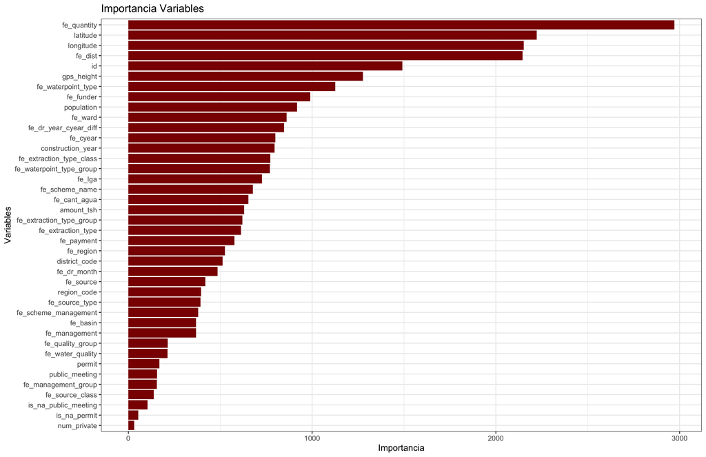

Observamos que las variables binarias *is_na* apenas tienen importancia en el modelo ¿Y si las eliminamos?

|  | Train.accuracy | Data.Submission |
| --- | --- | --- |
| Mejor accuracy hasta el momento | 0.8161616 | 0.8239 |
| Num + Cat (> 1 & < 10000) fe anteriores + lumping (mediana) + freq. abs. cat. (sin installer) + variables logicas | 0.8168855 | 0.8251 |
| Eliminando is_na_public_meeting e is_na_permit | 0.8171886 | 0.8235 |

Pese a la poca importancia que presentaban, eliminando ambas columnas ha provocado que el modelo empeore en cuanto a *score* se refiere. Por otro lado, tanto *public_meeting* como *permit* son muy similares en cuanto a importancia ¿Mejoraría el modelo si descartamos una de ellas?

|  | Train.accuracy | Data.Submission |
| --- | --- | --- |
| Mejor accuracy hasta el momento | 0.8161616 | 0.8239 |
| Num + Cat (> 1 & < 10000) fe anteriores + lumping (mediana) + freq. abs. cat. (sin installer) + variables logicas | 0.8168855 | 0.8251 |
| Eliminando is_na_public_meeting e is_na_permit | 0.8171886 | 0.8235 |
| Empleando solo permit (mas su columna is_na) | 0.8168519 | 0.8234 |
| Empleando solo public_meeting (mas su columna is_na) | 0.8172559 | 0.8236 |

Nuevamente, en ninguno de los casos el modelo se ve mejorado. **Por tanto, mantenemos ambas variables lógicas más sus correspondientes columnas *is_na***.

|  | Train.accuracy | Data.Submission |
| --- | --- | --- |
| Mejor accuracy en el concurso | - | 0.8180 |
| Num + Cat (> 1 & < 2100) fe anteriores + fe_funder + fe_ward | 0.8149832 | 0.8197 |
| Num + Cat (> 1 & < 2100) fe anteriores + lumping sobre funder + ward (mediana) | 0.8159764 | 0.8212 |
| Num + Cat (> 1 & < 2100) fe anteriores + lumping sobre funder + ward (tercer cuartil) | 0.8146633 | 0.8203 |
| Num + Cat (> 1 & < 2100) fe anteriores + lumping sobre funder + ward (primer cuartil) | 0.8159259 | 0.8196 |
| Num + Cat (> 1 & < 2100) fe anteriores + lumping (mediana) + hashed sobre funder + ward | 0.8158418 | 0.8214 |
| Num + Cat (> 1 & < 2100) fe anteriores + lumping (mediana) + freq. abs. sobre funder + ward | 0.8154882 | 0.8216 |
| Num + Cat (> 1 & < 2100) fe anteriores + lumping (mediana) + freq. abs. y target enc. (media) sobre funder + ward | 0.8154377 | 0.8164 |
| Num + Cat (> 1 & < 2100) fe anteriores + lumping (mediana) + freq. abs. y target enc. (suma) sobre funder + ward | 0.814899 | 0.8215 |
| Num + Cat (> 1 & < 2100) fe anteriores + lumping (mediana) + word embed sobre funder y ward (dim = 2) | 0.8155724 | 0.8204 |
| Num + Cat (> 1 & < 2100) fe anteriores + lumping (mediana) sobre funder y ward + freq. abs. cat. | 0.8157071 | 0.8226 |
| Num + Cat (> 1 & < 10000) fe anteriores + lumping (mediana) + freq. abs. cat. (sin installer) | 0.8161616 | 0.8239 |
| Num + Cat (> 1 & < 10000) fe anteriores + lumping (mediana) + freq. abs. cat. (sin installer) + variables logicas | 0.8168855 | 0.8251 |

### 3.1.13 Extracción de variables sobre date_recorded

#### Nuevas variables extraidas de date_recorded

Tras añadir las variables lógicas *public_meeting* y *permit*, hemos utilizado todas las variables disponibles hasta el momento. No obstante, una de los campos que, en mi opinión, no llegó a aprovecharse lo suficiente, fue *date_recorded*, del cual solo mantuvimos los campos:

1. *fe_month*: mes de *date_recorded*
2. *fe_dr_year_cyear_diff*: diferencia entre el año de *date_recorded* y el año de construcción.

No obstante, de dicho campo podemos aprovechar mucho más, extrayendo diferentes variables como las que se proponen a continuación:

1. *year*: durante el concurso en clase, acabamos descartando dicha variable al no aportar mejoría alguna al modelo. Sin embargo, con el *dataset* depurado hasta ahora ¿Mejorará si lo incluimos?
2. Podemos incluso añadir nuevas variables a partir de *date_recorded* como el **día**, el **día de la semana**, el **día del cuatrimestre**, la **semana**, el **cuatrimestre** o incluso **si el día en el que se registró la bomba de agua era fin de semana o no**.

Comenzando añadiendo nuevamente el campo *year* al *dataset* depurado hasta el momento, haciendo uso de la librería *lubridate*:

```r
#-- Icluimos year
year          <- c(year(dattrainOr$date_recorded), year(dattestOr$date_recorded))
datcompleto_imp$fe_dr_year <- year
```

|  | Train.accuracy | Data.Submission |
| --- | --- | --- |
| Mejor modelo hasta el momento | 0.8168855 | 0.8251 |
| Añadiendo year (date_recorded) | 0.8173064 | 0.8236 |

Nuevamente, nos encontramos con que la variable *year* no aporta mejoría alguna al modelo.

En contraposición, tal y como se mencionó anteriormente, podemos añadir nuevas variables extraídas a partir de *date_recorded*, gracias al paquete *lubridate* de *tidyverse*:

```r
#-- Incluimos otros campos, mediante el paquete lubridate
datcompleto_imp[, fe_dr_day :=  day(date_recorded)]        # Dia
datcompleto_imp[, fe_dr_wday := wday(date_recorded)]       # Dia de la semana
datcompleto_imp[, fe_dr_qday := qday(date_recorded)]       # Dia del cuatrimestre
datcompleto_imp[, fe_dr_week := week(date_recorded)]       # Semana
datcompleto_imp[, fe_dr_quarter := quarter(date_recorded)] # Cuatrimestre

#-- Incluimos si es o no fin de semana
datcompleto_imp[, fe_is_weekend := ifelse(fe_dr_wday %in% c(1,7), 1, 0)]
```

|  | Train.accuracy | Data.Submission |
| --- | --- | --- |
| Mejor modelo hasta el momento | 0.8168855 | 0.8251 |
| Añadiendo year (date_recorded) | 0.8173064 | 0.8236 |
| Incluyendo otros campos | 0.8165657 | 0.8224 |

Pese a incluir tantos campos, el modelo empeora. Analicemos el gráfico de importancia:

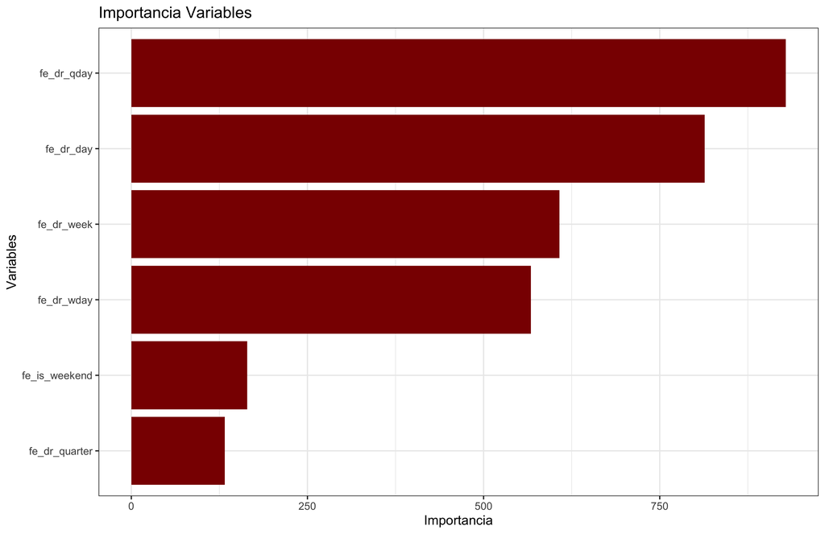

```r
knitr::include_graphics("../charts/20_lumping_fe_freq_abs_sobre_funder_ward_scheme_name_resto_categoricas_mas_logicas_fe_otros_campos.png")
```

**Nota**: para una mejor visualización, se han eliminado el resto de variables.

Podemos observar que variables como el cuatrimestre o si es o no fin de semana no presentan una importancia demasiado relevante, lo que podría estar provocando una disminución del *score* final ¿Mejoraría el modelo si descartamos ambas columnas?

|  | Train.accuracy | Data.Submission |
| --- | --- | --- |
| Mejor modelo hasta el momento | 0.8168855 | 0.8251 |
| Añadiendo year (date_recorded) | 0.8173064 | 0.8236 |
| Incluyendo otros campos | 0.8165657 | 0.8224 |
| Solo dr_qday, dr_day, dr_week y dr_wday | 0.8171212 | 0.8226 |

Descartando ambas variables, el modelo mejora ligeramente, aunque continua lejos del mejor *score* (0.8251). No obstante, podemos dar un salto más y eliminar las siguientes variables con menor importancia como el día de la semana ( *fe_dr_wday* ) y la semana ( *fe_dr_week* ):

|  | Train.accuracy | Data.Submission |
| --- | --- | --- |
| Mejor modelo hasta el momento | 0.8168855 | 0.8251 |
| Añadiendo year (date_recorded) | 0.8173064 | 0.8236 |
| Incluyendo otros campos | 0.8165657 | 0.8224 |
| Solo dr_qday, dr_day, dr_week y dr_wday | 0.8171212 | 0.8226 |
| Solo dr_qday y dr_day | 0.8175084 | 0.8242 |

Aunque bien es cierto que el modelo mejora de 0.8226 a 0.8242, continua estando lejos de 0.8251, incluso si solo mantuviéramos *fe_dr_qday*:

|  | Train.accuracy | Data.Submission |
| --- | --- | --- |
| Mejor modelo hasta el momento | 0.8168855 | 0.8251 |
| Añadiendo year (date_recorded) | 0.8173064 | 0.8236 |
| Incluyendo otros campos | 0.8165657 | 0.8224 |
| Solo dr_qday, dr_day, dr_week y dr_wday | 0.8171212 | 0.8226 |
| Solo dr_qday y dr_day | 0.8175084 | 0.8242 |
| Solo dr_qday | 0.8170202 | 0.8243 |

El *score* apenas mejora. Por tanto, **descartamos añadir cualquiera de las variables anteriores al modelo actual**.

#### Day_count

Hemos comprobado como, de todas las posibles variables que podían extraerse de *date_recorded*, las únicas que hemos mantenido han sido *fe_dr_year_cyear_diff* y *fe_dr_month*. No obstante, y en relación a *date_recorded*, podríamos crear una nueva variable, **similar a lo que realizamos en clase con construction_year** (restando a la variable un año de referencia: 2014).

Para empezar, **obtenemos una fecha de referencia, la fecha más reciente de la columna *date_recorded***:

```r
#-- Obtenemos una fecha de referencia (mas reciente)
date_recorded <- c(dattrainOr$date_recorded, dattestOr$date_recorded)
fecha_referencia <- max(ymd(date_recorded)) # Tenemos 2013-12-03
fecha_referencia
```

```
## [1] "2013-12-03"
```

Sabemos que la máxima fecha registrada corresponde con el 3 de diciembre del año 2013 **¿Y si creamos una nueva variable que almacenen la diferencia (en días) entre dicha fecha y los valores de *date_recorded*?**

```r
datcompleto_imp[fe_dr_day_count := as.numeric(fecha_referencia - ymd(date_recorded))]
```

|  | Train.accuracy | Data.Submission |
| --- | --- | --- |
| Mejor modelo hasta el momento | 0.8168855 | 0.8251 |
| Añadiendo day_count | 0.8168855 | 0.8247 |

Pese al añadir dicha variable, el modelo continua sin mejorar.

### Conclusión Feature Engineering

Tras realizar todos los pasos anteriores, por mejor *score* obtenido nos decantamos por el siguiente:

1. Seleccionar variables numéricas
2. Seleccionar variables categóricas (con menos de 10000 categorías), **a excepción de *installer***.
3. Aplicar la función *clean_text* sobre las variables categoricas (conversión a minúsculas, eliminación de espacios en blanco y signos de puntuación).
4. Aplicar *lumping* sobre las variables categóricas, **concretamente sobre la mediana en proporción de aparición**.
5. Añadir variables lógicas *permit* y *public_meeting*, imputando NAs por *missRanger*.

**Mejor *score* obtenido en DrivenData**: **0.8251**.